# Bachelor’s Thesis: Simulation Data EDA

Andrey Peshev

- prb = Percentage Relative Bias
- mcsd = Monte Carlo Standard Deviation
- Data generation equation: Y = 1.0 + 0.33X + 0.33Z1 + 0.33Z2 + Îµ

Simulation parameters:  
Proportion of the MAR predictor represented in the analysis model: pMAR = {1.0, 0.75, 0.5, 0.25, 0.0}  
Strength of correlations among the predictors: rXZ = {0.0, 0.1, 0.3, 0.5}  
Sample size: N = {100, 250, 500}  
Proportion of missing data: PM = {0.1, 0.2, 0.4}  
R<sup>2</sup> for the data generating model: R^2 = {0.15, 0.3, 0.6}

## Importing data and libraries

```r
#clear the working environment
rm(list=ls())

#import libraries
library(ggplot2)
library(dplyr)
#import data
all_data <- readRDS("data/masked_outcome_measures.rds")
data_prb <- all_data$prb
data_mcsd <- all_data$mcsd
```

## 1. Understanding the structure of the data

#### Data summaries

```r
#general summary of the data
summary(data_prb)
```

```
 a              b        c        d        e        f        g             int                  x
 1: 540   8      :1620   1:3060   1:1836   1:3060   1:3060   1:2295   Min.   :-11.09768   Min.   :-12.5372
 2:4320   1      :1080   2:3060   2:1836   2:3060   2:3060   2:2295   1st Qu.: -2.39193   1st Qu.: -2.2738
 3:4320   2      :1080   3:3060   3:1836   3:3060   3:3060   3:2295   Median : -0.11230   Median : -0.9350
          3      :1080            4:1836                     4:2295   Mean   : -1.54879   Mean   : -1.5971
          4      :1080            5:1836                              3rd Qu.:  0.07464   3rd Qu.: -0.2522
          5      :1080                                                Max.   :  2.63082   Max.   :  3.3879
          (Other):2160
       z1
 Min.   :-24.8349
 1st Qu.: -2.0565
 Median : -0.2028
 Mean   : -1.0290
 3rd Qu.:  0.3947
 Max.   : 10.5551
```

```r
summary(data_mcsd)
```

```
 a              b        c        d        e        f        g             int                x
 1: 540   8      :1620   1:3060   1:1836   1:3060   1:3060   1:2295   Min.   :0.02693   Min.   :0.02767
 2:4320   1      :1080   2:3060   2:1836   2:3060   2:3060   2:2295   1st Qu.:0.05579   1st Qu.:0.06394
 3:4320   2      :1080   3:3060   3:1836   3:3060   3:3060   3:2295   Median :0.08375   Median :0.09724
          3      :1080            4:1836                     4:2295   Mean   :0.09690   Mean   :0.11486
          4      :1080            5:1836                              3rd Qu.:0.12393   3rd Qu.:0.15173
          5      :1080                                                Max.   :0.37215   Max.   :0.46496
          (Other):2160
       z1
 Min.   :0.02692
 1st Qu.:0.06128
 Median :0.09071
 Mean   :0.10765
 3rd Qu.:0.13796
 Max.   :0.50264
```

Columns **a** through **g** are the different conditions of the simulation. An interesting thing to note is that condition **1** of parameter **a** has only 540 occurrences and condition **8** of parameter **b** has 1620.

#### Number of unique conditions for each parameter:

```r
str(data_prb)
```

```
'data.frame':   9180 obs. of  10 variables:
 $ a  : Factor w/ 3 levels "1","2","3": 2 2 2 2 2 2 2 2 2 2 ...
 $ b  : Factor w/ 8 levels "1","2","3","4",..: 8 7 6 5 4 3 2 1 8 7 ...
 $ c  : Factor w/ 3 levels "1","2","3": 1 1 1 1 1 1 1 1 2 2 ...
 $ d  : Factor w/ 5 levels "1","2","3","4",..: 5 5 5 5 5 5 5 5 5 5 ...
 $ e  : Factor w/ 3 levels "1","2","3": 3 3 3 3 3 3 3 3 3 3 ...
 $ f  : Factor w/ 3 levels "1","2","3": 1 1 1 1 1 1 1 1 1 1 ...
 $ g  : Factor w/ 4 levels "1","2","3","4": 1 1 1 1 1 1 1 1 1 1 ...
 $ int: num  0.0825 0.0902 0.0949 0.1067 0.0986 ...
 $ x  : num  0.658 0.631 0.595 0.555 0.566 ...
 $ z1 : num  0.251 0.296 0.268 0.299 0.32 ...
```

The analysis will begin with the PRB because it is necessary to understand which conditions are biased in order to make cross-references with the MCSD.

#### Boxplots with condition on the x-axis and PRB on y-axis for int, x, z1:

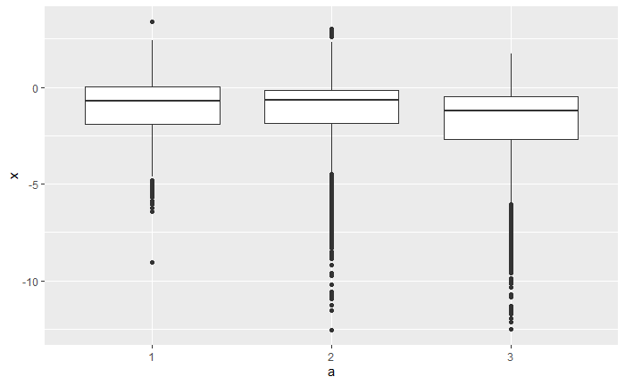

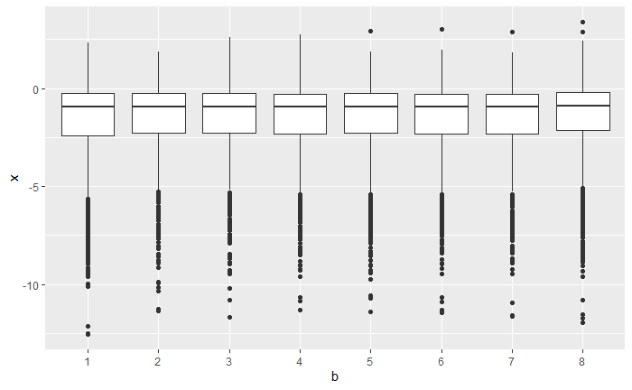

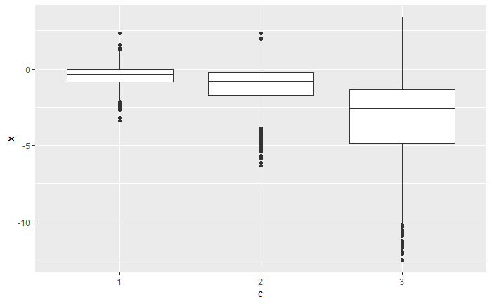

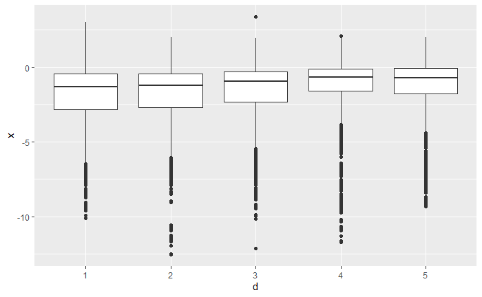

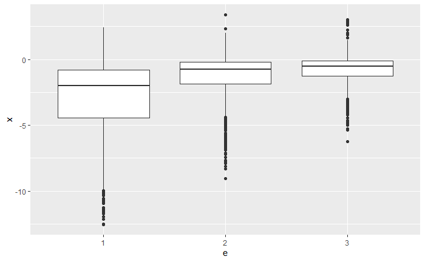

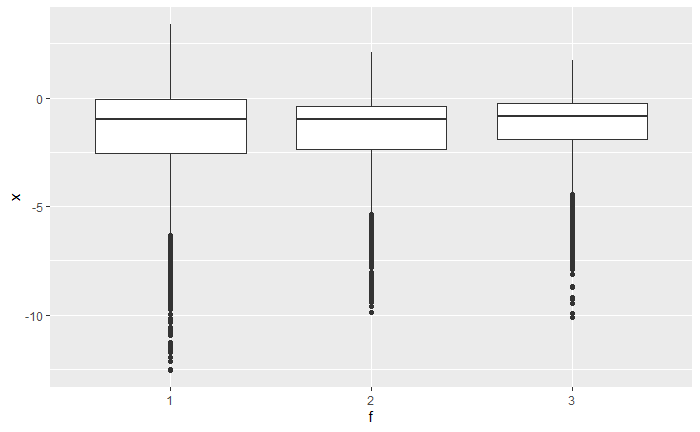

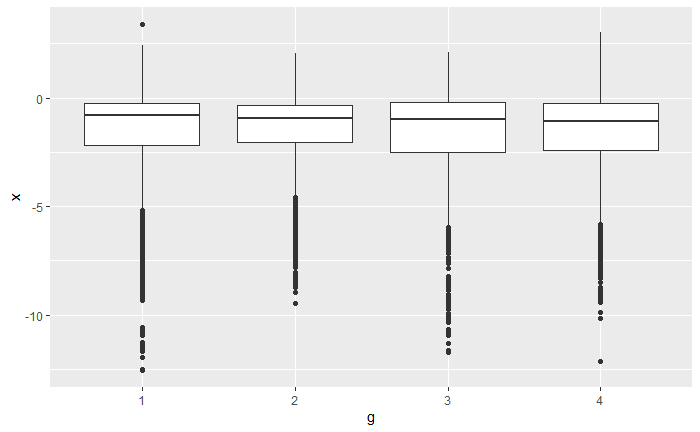

```r
#boxplots for prb with the different conditions for x
for (i in 1:length(data_prb[1:7])){
  print(ggplot(data_prb, aes(x=data_prb[, i], y=x)) + geom_boxplot() + xlab(colnames(data_prb[i])))
}
```

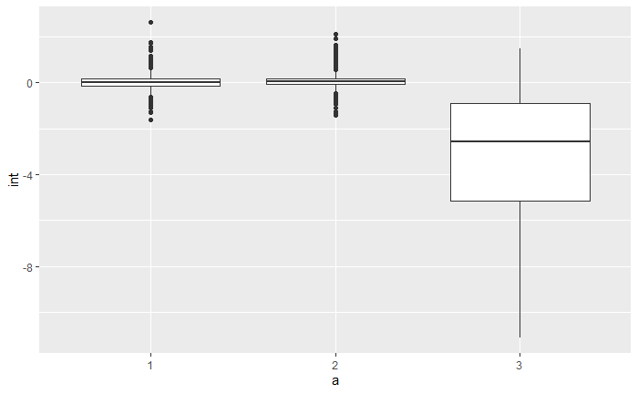

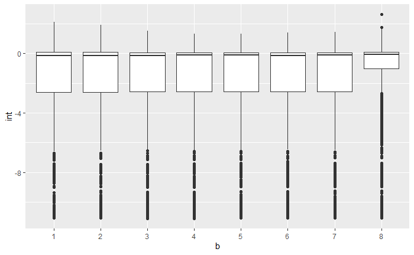

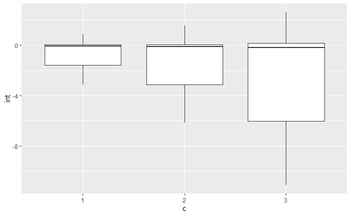

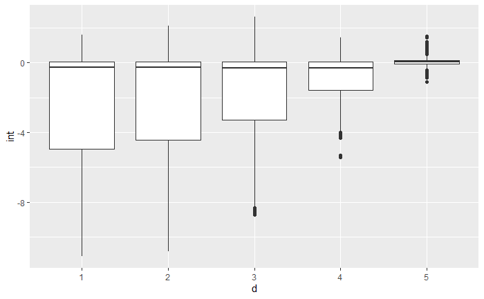

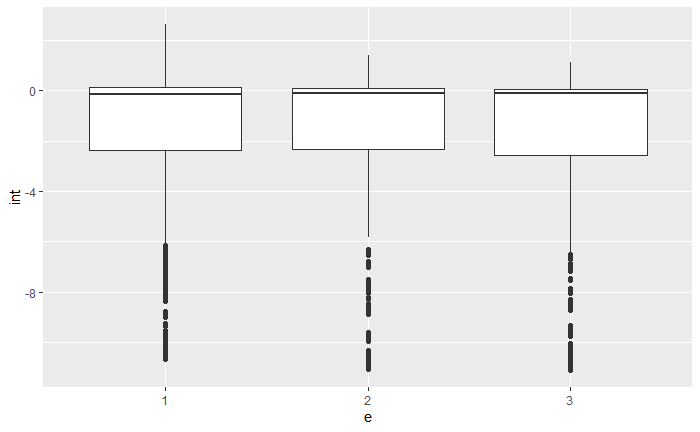

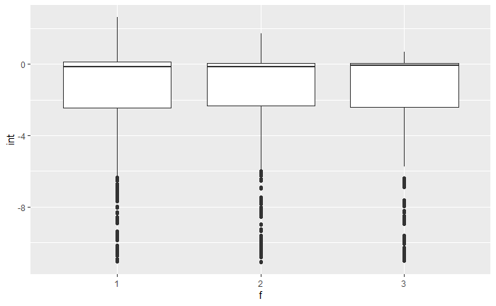

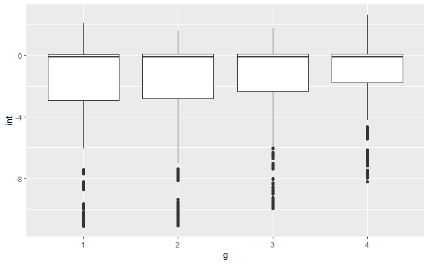

```r
#boxplots for prb with the different conditions for int
for (i in 1:length(data_prb[1:7])){
  print(ggplot(data_prb, aes(x=data_prb[, i], y=int)) + geom_boxplot() + xlab(colnames(data_prb[i])))
}
```

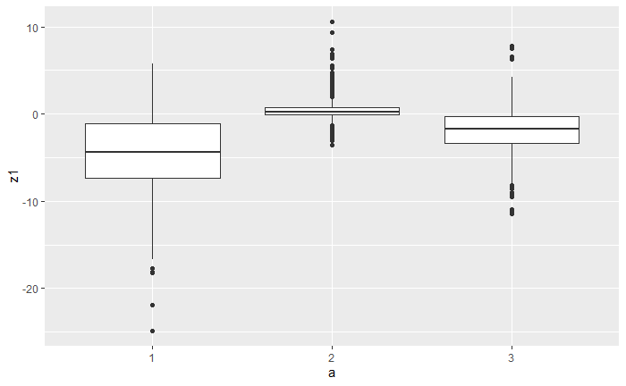

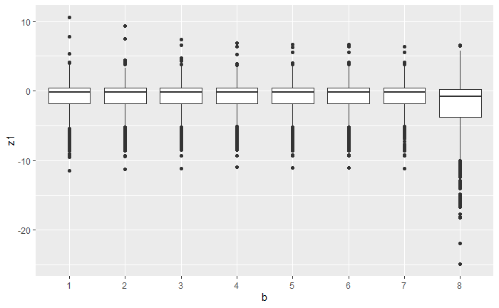

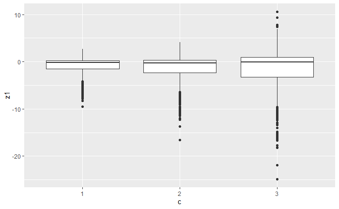

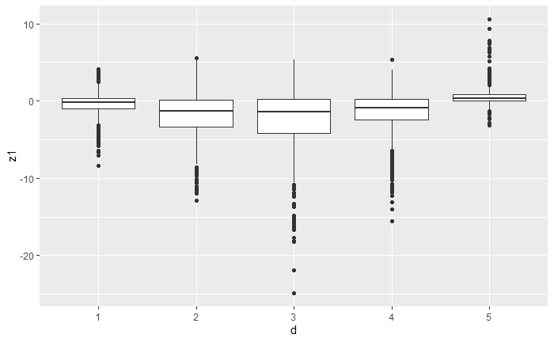

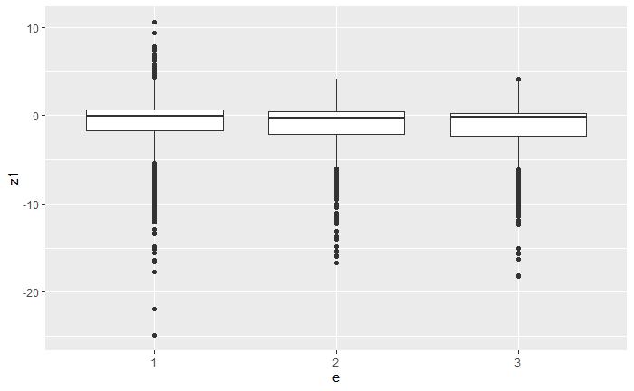

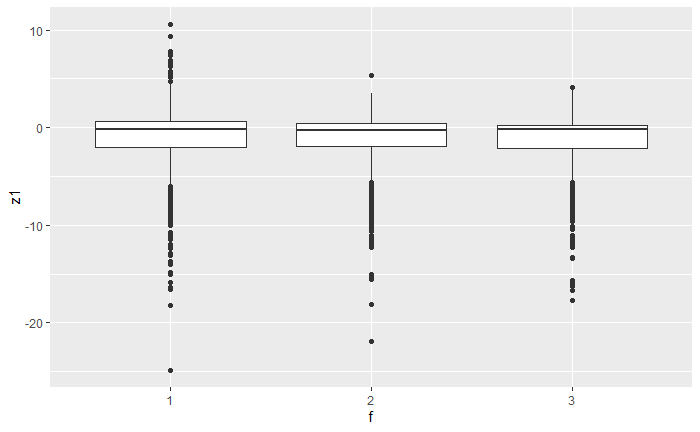

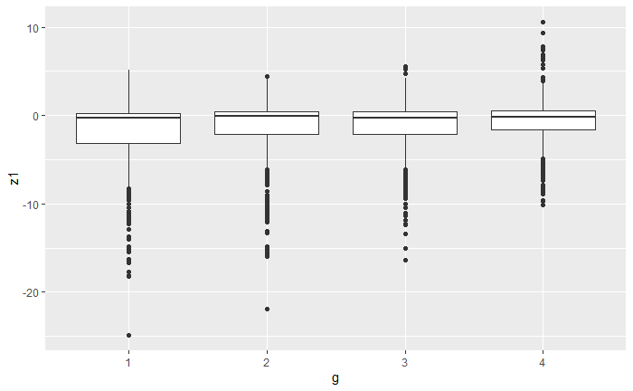

```r
#boxplots for prb with the different conditions for z1
for (i in 1:length(data_prb[1:7])){
  print(ggplot(data_prb, aes(x=data_prb[, i], y=z1)) + geom_boxplot() + xlab(colnames(data_prb[i])))
}
```

Parameter **a**: The largest PRB for the slope and intercept is in condition **3** and in condition **1** for the auxiliary variable.

Parameter **c**: The highest mean PRB for **x** is in condition **3**. For **int** the mean is the same across conditions, however the IQR increases. Same goes for **z1**, although the increase is not as drastic. Parameter **d**: The IQR decreases for **x** until condition **4**. For **int** the IQR decreases drastically. For **z1** the situation is more interesting - The IQR increases until condition **3** and then decreases again.

Parameter **e**: The IQR decreases in each condition for **x**. For **int** and **z1** the PRB distribution looks identical across conditions, except for the many outliers in condition **1** for **z1**.

Parameter **f**: There seems to be no visible difference across the conditions for all three parameters.

Parameter **g**: The IQR becomes smaller for **int** and **z1**. Almost no difference in conditions for **x**.

```r
# min and max PRB for x
data_prb[which.min(abs(data_prb$x)),]
```

|  | a | b | c | d | e | f | g | int | x | z1 |
| --- | --- | --- | --- | --- | --- | --- | --- | --- | --- | --- |
| 824 | 2 | 1 | 1 | 1 | 3 | 3 | 1 | -0.03030713 | 0.0001266817 | -0.05231698 |

```r
data_prb[which.max(abs(data_prb$x)),]
```

|  | a | b | c | d | e | f | g | int | x | z1 |
| --- | --- | --- | --- | --- | --- | --- | --- | --- | --- | --- |
| 336 | 2 | 1 | 3 | 2 | 1 | 1 | 1 | 2.101071 | -12.53718 | -0.6113876 |

```r
# min and max PRB for int
data_prb[which.min(abs(data_prb$int)),]
```

|  | a | b | c | d | e | f | g | int | x | z1 |
| --- | --- | --- | --- | --- | --- | --- | --- | --- | --- | --- |
| 5063 | 3 | 2 | 3 | 5 | 3 | 3 | 1 | -2.924884e-05 | -0.6614611 | 0.08188704 |

```r
data_prb[which.max(abs(data_prb$int)),]
```

|  | a | b | c | d | e | f | g | int | x | z1 |
| --- | --- | --- | --- | --- | --- | --- | --- | --- | --- | --- |
| 4797 | 3 | 4 | 3 | 1 | 3 | 2 | 1 | -11.09768 | -2.950285 | -0.2549101 |

```r
# min and max PRB for z1
data_prb[which.min(abs(data_prb$z1)),]
```

|  | a | b | c | d | e | f | g | int | x | z1 |
| --- | --- | --- | --- | --- | --- | --- | --- | --- | --- | --- |
| 2006 | 2 | 3 | 2 | 2 | 2 | 3 | 2 | -0.00645223 | -0.416562 | -4.107968e-05 |

```r
data_prb[which.max(abs(data_prb$z1)),]
```

|  | a | b | c | d | e | f | g | int | x | z1 |
| --- | --- | --- | --- | --- | --- | --- | --- | --- | --- | --- |
| 30510 | 1 | 8 | 3 | 3 | 1 | 1 | 1 | 0.02735404 | 0.4064208 | -24.83494 |

```r
NA
```

```r
xtabs(~ a+b, data=data_prb)
```

```
   b
a     1   2   3   4   5   6   7   8
  1   0   0   0   0   0   0   0 540
  2 540 540 540 540 540 540 540 540
  3 540 540 540 540 540 540 540 540
```

Condition 1 for the a parameter is only paired with condition 8 of the b parameter.

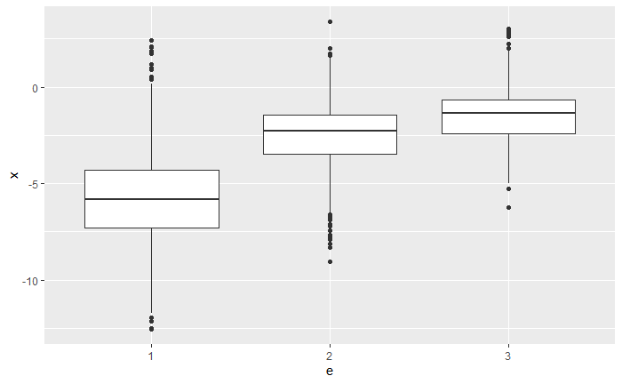

```r
data_prb %>% filter(c==3) %>% ggplot(aes(x=e, y=x)) + geom_boxplot()
```